# PA1_template.Rmd

Paul Yap

11 December, 2014

# Loading and preprocessing the data

```r
library(knitr)
#Prepares the file for download and read to table
unzip("repdata-data-activity.zip") #unzip the file above to working directory
activity_table<-read.csv("activity.csv",sep = ",",h=T) #create the table
```

# What is mean total number of steps taken per day?

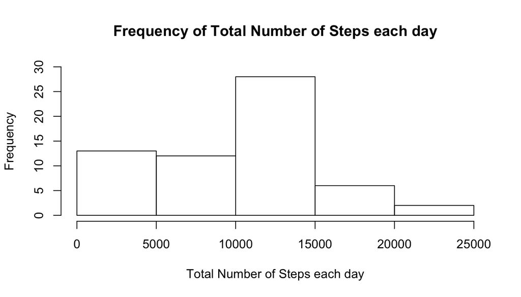

```r
meantotal_steps<-sapply(split(activity_table$steps,activity_table$date),sum,na.rm=TRUE)
hist(meantotal_steps,xlab="Total Number of Steps each day",main="Frequency of Total Number of Steps each day",ylim=c(0,30))
```

```r
#calculate the mean and media
meantotal_steps_table<-as.data.frame(meantotal_steps)
colnames(meantotal_steps_table)<-c("total_steps")
Mean_Steps<-mean(meantotal_steps_table$total_steps)
Median_Steps<-median(meantotal_steps_table$total_steps)
```

## 2) The mean total number of steps each day is 9,354.23.

## The median total number of steps each day is 10,395.

# What is the average daily activity pattern?

## 1) Make a time series plot (i.e. type = “l”) of the 5-minute interval (x-axis) and the average number of steps taken, averaged across all days (y-axis)

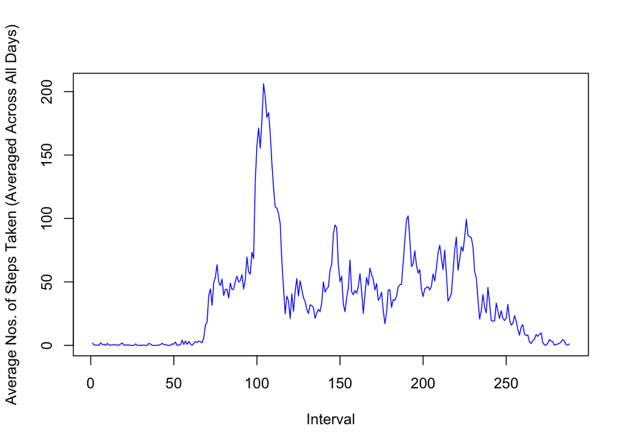

```r
#prepare data frame to calculate the avg number of steps taken (averaged across all days) across the unique time interval
activity_table<-read.csv("activity.csv",sep = ",",h=T) #create the table
activity_table$interval<-as.factor(activity_table$interval) #factorize the interval for plotting
interval_avgsteps_agg<-aggregate(activity_table$steps~activity_table$interval,FUN=mean,na.rm=T)
colnames(interval_avgsteps_agg)<-c("interval","avg_steps")

interval_avgsteps_agg$interval<-as.integer(interval_avgsteps_agg$interval) #change to integer so that lines can be drawn
plot(interval_avgsteps_agg$interval,interval_avgsteps_agg$avg_steps,type="l",col="blue",xlab="Interval",ylab="Average Nos. of Steps Taken (Averaged Across All Days)")
```

```r
#to find the 5-min interval with the maximum number os steps
max_steps<-max(interval_avgsteps_agg$avg_steps)
max_stepsinterval<-interval_avgsteps_agg[interval_avgsteps_agg$avg_steps%in%max_steps,1]
```

[output not shown]

# Inputing missing values

## 1) Calculate and report the total number of missing values in the dataset (i.e. the total number of rows with NAs)

```r
number_rows<-nrow(activity_table)
number_na<-sum(is.na(activity_table))
```

## 3) Create a new dataset that is equal to the original dataset but with the missing data filled in.

```r
activity_table<-read.csv("activity.csv",sep = ",",h=T) #create the table
activity_table$interval<-as.factor(activity_table$interval) #factorize the interval for plotting
activity_table2<-activity_table[!is.na(activity_table$steps),] #create a new table removing the NA
activity_table3<-activity_table #create a new table that includes the NA
date_avgsteps_agg<-aggregate(activity_table2$steps, by=list(activity_table2$date,activity_table2$interval),FUN=mean,na.rm=T)
colnames(date_avgsteps_agg)<-c("date","interval","steps")
activity_table2$unique<-paste(activity_table2$date, "_",activity_table2$interval) #create unique identifier with date and interval
activity_table3$unique<-paste(activity_table3$date, "_",activity_table3$interval) #create unique identifier with date and interval
date_avgsteps_agg$unique<-paste(date_avgsteps_agg$date,"_",date_avgsteps_agg$interval) #create unique identifier with date and interval

#match the unique identifider with activity_table3's identifier and if they match, paste the row/s to activity_table3
for (i in 1:nrow(date_avgsteps_agg)){
if (grep(date_avgsteps_agg$unique[i],activity_table3$unique)>0)
 rbind(date_avgsteps_agg[i,], activity_table3)
}
```

## 4) Make a histogram of the total number of steps taken each day and calculate and report the mean and median total number of steps taken per day. Do these values differ from the estimates from the first part of the assignment? What is the impact of imputing missing data on the estimates of the total daily number of steps?

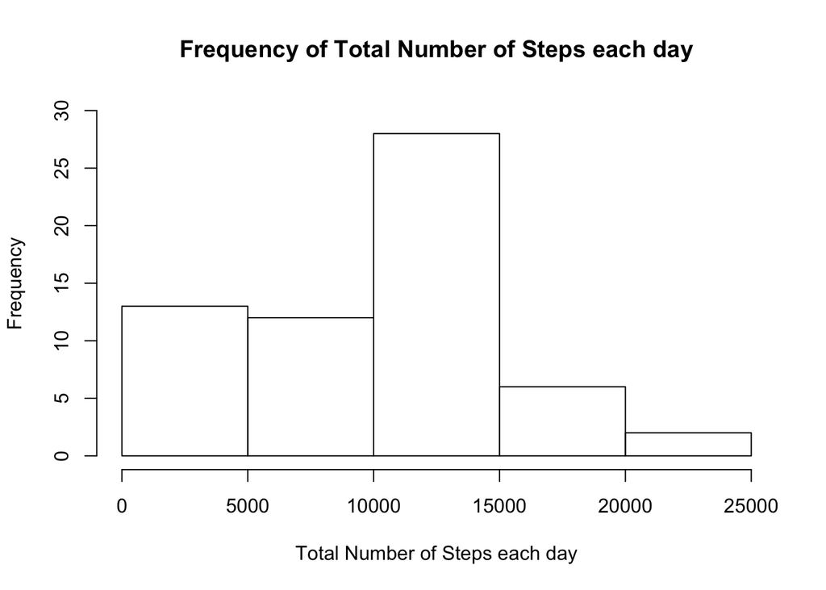

```r
meantotal_steps2<-sapply(split(activity_table3$steps,activity_table3$date),sum,na.rm=TRUE)
hist(meantotal_steps2,xlab="Total Number of Steps each day",main="Frequency of Total Number of Steps each day",ylim=c(0,30))
```

```r
#calculate the mean and media
meantotal_steps_table2<-as.data.frame(meantotal_steps2)
colnames(meantotal_steps_table2)<-c("total_steps")
Mean_Steps2<-mean(meantotal_steps_table2$total_steps)
Median_Steps2<-median(meantotal_steps_table2$total_steps)
```

## Mean = 9,354.23 and Median = 10,395.

# Are there differences in activity patterns between weekdays and weekends?

## 1) Create a new factor variable in the dataset with two levels – “weekday” and “weekend” indicating whether a given date is a weekday or weekend day.

```r
activity_table3$day<-as.POSIXct(strptime(activity_table3$date, "%Y-%m-%d"))
activity_table3$day<-weekdays(activity_table3$day)
activity_table3$day<-as.character(activity_table3$day)

for (i in 1:nrow(activity_table3)){
if(activity_table3$day[i]%in%c("Saturday","Sunday"))
  activity_table3$day[i]<-"Weekend"
  else
  activity_table3$day[i]<-"Weekday"
}
activity_table3$interval<-as.factor(activity_table3$interval) #factorize the interval for plotting
interval_avgsteps_agg2 <-aggregate(activity_table3$steps,by=list(activity_table3$interval,activity_table3$day),FUN=mean,na.rm=T)
colnames(interval_avgsteps_agg2)<-c("interval","day","avg_steps")
```

## 2)Make a panel plot containing a time series plot (i.e. type = “l”) of the 5-minute interval (x-axis) and the average number of steps taken, averaged across all weekday days or weekend days (y-axis). See the README file in the GitHub repository to see an example of what this plot should look like using simulated data.

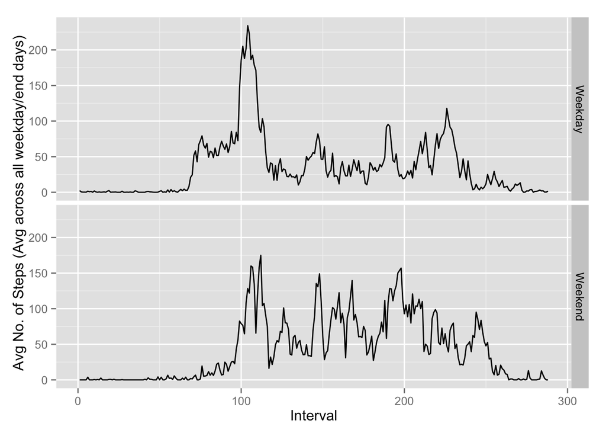

```r
library(ggplot2)
interval_avgsteps_agg2$interval<-as.integer(interval_avgsteps_agg2$interval)#change to integer so that lines can be drawn
qplot(interval,avg_steps, data=interval_avgsteps_agg2,facets=day~.,xlab="Interval",ylab="Avg No. of Steps (Avg across all weekday/end days)",geom=c("line"))
```